# CPLN 0795 - Class 8

Michael Fichman

2024-08-19

# Start a Github Account, Fork this repo and clone it

1. Start a github account and download github desktop
2. Find the repository for this class and “fork” it - https://github.com/mafichman/cpln_0795
3. Open Github Desktop, and navigate to file -> clone repository. Navigate to the cpln_0795 repo and clone it - it should have populated in your menu
4. Open class_8_2024.rmd in R Studio.

# The Tutorial

Learning Goals:

- Running more R code
- Doing geoprocessing and spatial summaries using R
- Familiarity with GitHub and R Markdown

Today we are going to load our Philadelphia ACS data that we have been working with all course long using `tidycensus` - a package that interfaces with the Census API. We are going to reprise our lesson from last week where we made a spatial summary of point data - illegal dumping incidents, summarized by census tract, then normalized to the tract area or population.

We are going to work in R Markdown, basically just running code, and at the end, you can “knit” your own markdown and push it back to your Github repo.

# Start by Clearing Your Workspace

Go to the session tab in R Studio and Clear Workspace to get old objects out of your environment if there are any.

# Load Our Libraries

Don’t have a package installed? Run install.packages(“name_of_package”) once, and then it’s on your computer ready to be called into your environment using `library`

# Load your census API key

You will need an API key to use tidycensus. Go get one here:

https://api.census.gov/data/key_signup.html

Paste your key into the space below and run the function `census_api_key`

```r
census_api_key("ea48b950b6328a9a01bcfcb61fed774c017b877a", overwrite = TRUE)
```

```
## To install your API key for use in future sessions, run this function with `install = TRUE`.
```

# Load Variables

Let’s load the Census data dictionary from `tidycensus`

```r
acs_variable_list <- load_variables(2020, #year
                                    "acs5", #five year ACS estimates
                                    cache = TRUE)
```

What does `load_variables` do?

We can use the `??` command to look at the documentation of any function in R.

```r
??load_variables
```

```
## starting httpd help server ... done
```

We want to DL Philadelphia 2020 tract-level ACS data.

I like to do this by creating a list of variables to grab that we can feed to tidycensus. The “E” on the end of the code means “Estimate.”

```r
acs_vars <- c("B01001_001E", # ACS total Pop estimate
              "C02003_004E", # One race black
              "C02003_003E", # One race white
              "B03001_003E", # Hispanic (all)
              "B02001_005E", # AAPI
              "B11012_001E", # n Households
              "B08137_003E", # Renter hh
              "B08137_002E", # owner hh
              "B06011_001E") # Median income in past 12 months
```

# Tidycensus Call

If you don’t know what get_acs is, try ??get_acs

Note that geometry = TRUE - we are asking for a shp/geojson/sf type object. If we said FALSE, we’d just get a flat file data frame.

```r
acs2020 <- get_acs(geography = "tract",
                   year = 2020,
                   variables = acs_vars,
                   geometry = TRUE,
                   state = "PA",
                   county = "Philadelphia",
                   output = "wide")
```

[output not shown]

# Clean data

Let’s use a dplyr pipe to chain some commands together and clean our data. You should be familiar with all of these columns - this is how I created our data sets for the other classes, it was easy!

Look at each step in the chain - we overwrite `acs2020` by creating a new object called `acs2020`, that consisits of our ACS data, with only the GEOID, NAME and our `acs_vars` (e.g. just the Estimates) selected. We `rename` these to be something more intelligible, and then we use `mutate` to make some new columns.

```r
acs2020 <- acs2020 %>%
  select(GEOID, NAME, acs_vars) %>%
  rename(pop = B01001_001E,
         med_inc = B06011_001E,
         blk_tot = C02003_004E,
         wht_tot = C02003_003E,
         hsp_tot = B03001_003E,
         aapi_tot = B02001_005E,
         hhs = B11012_001E,
         renter_hh = B08137_003E,
         owner_hh = B08137_002E) %>%
  mutate(year = 2020,
         pct_wht = 100*(wht_tot/pop),
         pct_blk = 100*(blk_tot/pop),
         pct_hsp = 100*(hsp_tot/pop),
         pct_aapi = 100*(aapi_tot/pop),
         rent_pct = 100*(renter_hh / hhs))
```

# Load the 311 data

Our 311 data from Class 3 are hosted online at my class repo - you can use `st_read` to read a spatial data object right in from the internet using the URL.

Prompt - run this section of code on your own, we did this stuff yesterday.

```r
philly_311 <- st_read("https://raw.githubusercontent.com/mafichman/cpln_0795/main/data/philly_311.geojson")
```

## Explore 311 data

Check out the data, these are points.

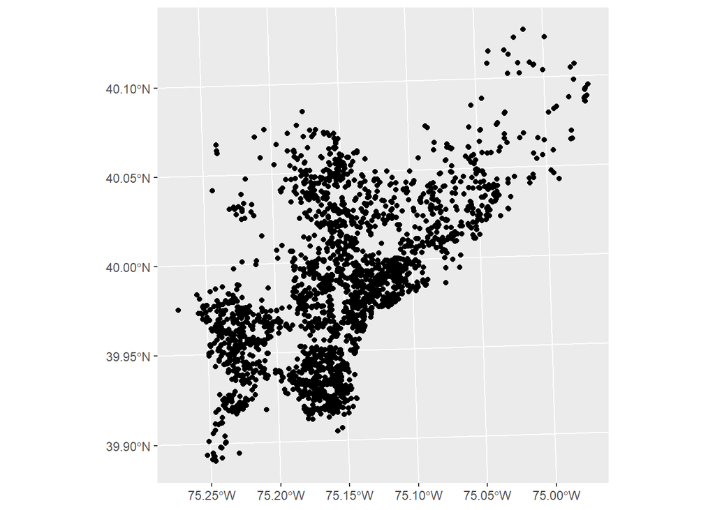

```r
ggplot()+
  geom_sf(data = philly_311)
```

We can check the CRS

```r
st_crs(philly_311)
```

```
## Coordinate Reference System:
##   User input: NAD83 / Pennsylvania South (ftUS)
##   wkt:
## PROJCRS["NAD83 / Pennsylvania South (ftUS)",
##     BASEGEOGCRS["NAD83",
##         DATUM["North American Datum 1983",
##             ELLIPSOID["GRS 1980",6378137,298.257222101,
##                 LENGTHUNIT["metre",1]]],
##         PRIMEM["Greenwich",0,
##             ANGLEUNIT["degree",0.0174532925199433]],
##         ID["EPSG",4269]],
##     CONVERSION["SPCS83 Pennsylvania South zone (US survey foot)",
##         METHOD["Lambert Conic Conformal (2SP)",
##             ID["EPSG",9802]],
##         PARAMETER["Latitude of false origin",39.3333333333333,
##             ANGLEUNIT["degree",0.0174532925199433],
##             ID["EPSG",8821]],
##         PARAMETER["Longitude of false origin",-77.75,
##             ANGLEUNIT["degree",0.0174532925199433],
##             ID["EPSG",8822]],
##         PARAMETER["Latitude of 1st standard parallel",40.9666666666667,
##             ANGLEUNIT["degree",0.0174532925199433],
##             ID["EPSG",8823]],
##         PARAMETER["Latitude of 2nd standard parallel",39.9333333333333,
##             ANGLEUNIT["degree",0.0174532925199433],
##             ID["EPSG",8824]],
##         PARAMETER["Easting at false origin",1968500,
##             LENGTHUNIT["US survey foot",0.304800609601219],
##             ID["EPSG",8826]],
##         PARAMETER["Northing at false origin",0,
##             LENGTHUNIT["US survey foot",0.304800609601219],
##             ID["EPSG",8827]]],
##     CS[Cartesian,2],
##         AXIS["easting (X)",east,
##             ORDER[1],
##             LENGTHUNIT["US survey foot",0.304800609601219]],
##         AXIS["northing (Y)",north,
##             ORDER[2],
##             LENGTHUNIT["US survey foot",0.304800609601219]],
##     USAGE[
##         SCOPE["Engineering survey, topographic mapping."],
##         AREA["United States (USA) - Pennsylvania - counties of Adams; Allegheny; Armstrong; Beaver; Bedford; Berks; Blair; Bucks; Butler; Cambria; Chester; Cumberland; Dauphin; Delaware; Fayette; Franklin; Fulton; Greene; Huntingdon; Indiana; Juniata; Lancaster; Lawrence; Lebanon; Lehigh; Mifflin…
##         BBOX[39.71,-80.53,41.18,-74.72]],
##     ID["EPSG",2272]]
```

Does it match the thing we want to join it to?

```r
st_crs(acs2020)
```

```
## Coordinate Reference System:
##   User input: NAD83
##   wkt:
## GEOGCRS["NAD83",
##     DATUM["North American Datum 1983",
##         ELLIPSOID["GRS 1980",6378137,298.257222101,
##             LENGTHUNIT["metre",1]]],
##     PRIMEM["Greenwich",0,
##         ANGLEUNIT["degree",0.0174532925199433]],
##     CS[ellipsoidal,2],
##         AXIS["latitude",north,
##             ORDER[1],
##             ANGLEUNIT["degree",0.0174532925199433]],
##         AXIS["longitude",east,
##             ORDER[2],
##             ANGLEUNIT["degree",0.0174532925199433]],
##     ID["EPSG",4269]]
```

Let’s transform the CRS of `acs2020` to conform to the philly_311 projection - 2272.

Where did 2272 come from? Check out spatialreference.org for a list of all the CRS numbers and details about them.

```r
acs2020 <- acs2020 %>%
  st_transform(crs = 2272)
```

# ACS and 311 data together

## Plotting

Now that everything is in the same CRS, let’s look at both things together on a plot.

Let’s set acs2020 to just be all black, no aes() visualization here, and let’s set our linework to transparent.

We can vary the aesthetics of the points to see if we can get a better looking map. I’m going to make the points yellow, adjust the alpha (aka transparency), and fiddle with the “size” parameter.

Prompt: Try it yourself - change the color and the alpha.

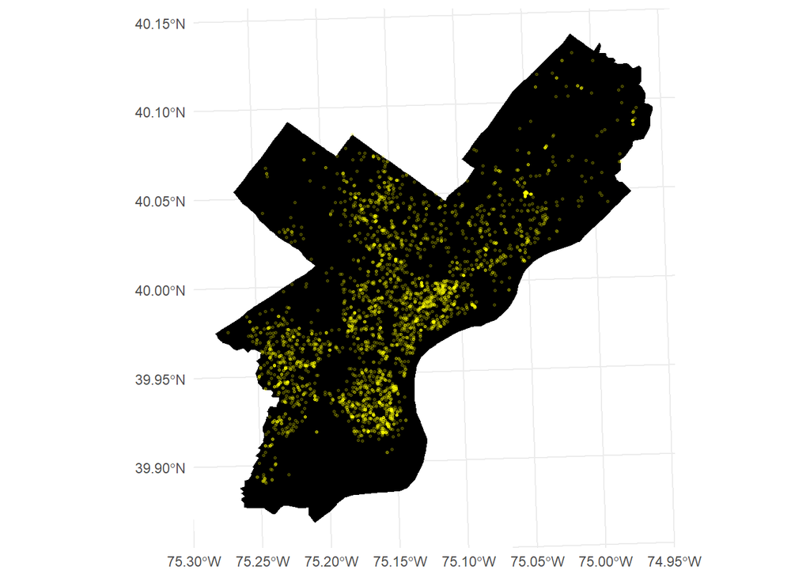

```r
ggplot()+
  geom_sf(data = acs2020,
          fill = "black", color = "transparent")+
  geom_sf(data = philly_311,
          color = "yellow", alpha = 0.2,
          size = .5)+
  theme_minimal()
```

## Spatial join and tract-level summary

We will do what we did last week - relating 311 calls to tracts and then sumamrizing to find out how many points are in each tract. This is pretty simply done - here we initiate the join from `philly_311`. Try it and then look at the result using `glimpse()`

```r
points_and_tracts <- st_join(philly_311, acs2020)
```

OK, that’s nice, but let’s clean it up a bit so that all we are dealing with on the acs side is the GEOID.

Ultimately, we just need to summarize by the tract ID … why is that?

```r
points_and_tracts <- st_join(philly_311, acs2020 %>%
                               select(GEOID))
```

To make a summary, we use the `group_by` and `summarize` commands.

We are going to turn our point data into a dataframe - `dplyr` - the data wrangling package in the `tidyverse` is fussy about spatial objects sometimes because it doesn’t know what to do about the “geometry” column.

```r
tract_dumping_summary <- points_and_tracts %>%
  as.data.frame() %>%
  group_by(GEOID) %>%
  summarize(n = n())
```

Examine these data, what do they look like?

Now we can join it back to our ACS data using a tabular join

Examine each table before you do this so you can see what’s about to happen… and then examine it afterwards.

```r
acs2020_incidents <- left_join(acs2020, tract_dumping_summary, by = "GEOID")
```

There are a bunch of NA observations in our joined data. Why?

Remember to be wary of NA data - what do these data represent?

We use an `ifelse` statement here - that’s known as a “boolean” - remember that from last class?

If the observation column `n` is an NA, turn it into a zero, else, leave it as `n` - as is.

```r
acs2020_incidents <- acs2020_incidents %>%
  mutate(n = ifelse(is.na(n) == TRUE, 0, n))
```

# Mapping 311

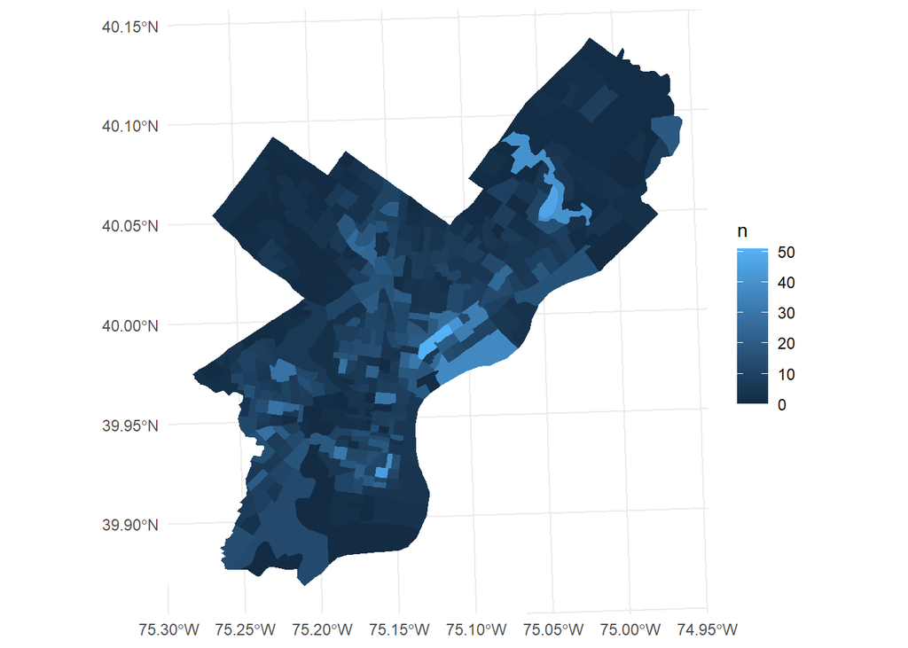

```r
ggplot()+
  geom_sf(data = acs2020_incidents,
          aes(fill = n), color = "transparent")+
  theme_minimal()
```

# Calculating Geometry

The `st_area` function is basically “calculate geometry.”

```r
acs2020_incidents <- acs2020_incidents %>%
  mutate(area = st_area(.))
```

When you do geoprocessing in R, you get area and distance measurements IN THE LINEAR UNIT OF THE PROJECTION - projections are important! For the record, there are 27878555.87 square feet in a square mile. Yes imperial units are annoying! So let’s manually do a transformation - note that I convert it to numeric to get rid of that notation from the area column

```r
acs2020_incidents <- acs2020_incidents %>%
  mutate(area_sqmi = as.numeric(area/27878555.87))
```

# Mapping and analysis workshop

Your job now is to create some new code chunks in your markdown and knit it.

## Chunk 1 - Creating normalized measures of incident density

Using the `mutate` command, create a column with a normalized measures of incident intensity. Choose one of these two options:

- `n_per_10k` (incidents per 10,000 people) or
- `n_per_sqmi` and (incidents per square mile)

```r
acs2020_incidents <- acs2020_incidents%>%
                    mutate(n_per_sqmi=n/area_sqmi)
```

## Chunk 2 & 3 - Getting Some Spatial Data for Mapping

Get some hydrology data from the `tigris` package to make the map so nice.

Here is how you do this - I am going to be a bit general in how I describe this, so make sure you use the documentation in the R Studio viewer OR do some internet sleuthing to figure out how to make this work.

Use the `area_water` function from tigris, and request data of the class `sf` for Philadelphia county. This will call the data from the census spatial library of hydro features.

When you have those data, make sure they are projected to 2272 using `st_crs`, if not, st_transform them.

Download the Philly Council districts using `st_read` and be ready to lay those on top.

```r
philly_water <- area_water(42,101,year=2020) %>%
st_transform(2272)
```

[output not shown]

# Chunks 4 & 5

Make a chloropleth map of one of the measures (See the above tab “Mapping 311” or some of yesterday’s code for an example of how to do this.)

Add a title, subtitle and caption (with data attribution) to the map.

Change the color ramp if possible

Add council districts on top with the fill set to transparent

Add some annotation - what are your observations regarding the spatial process of these 311 calls?

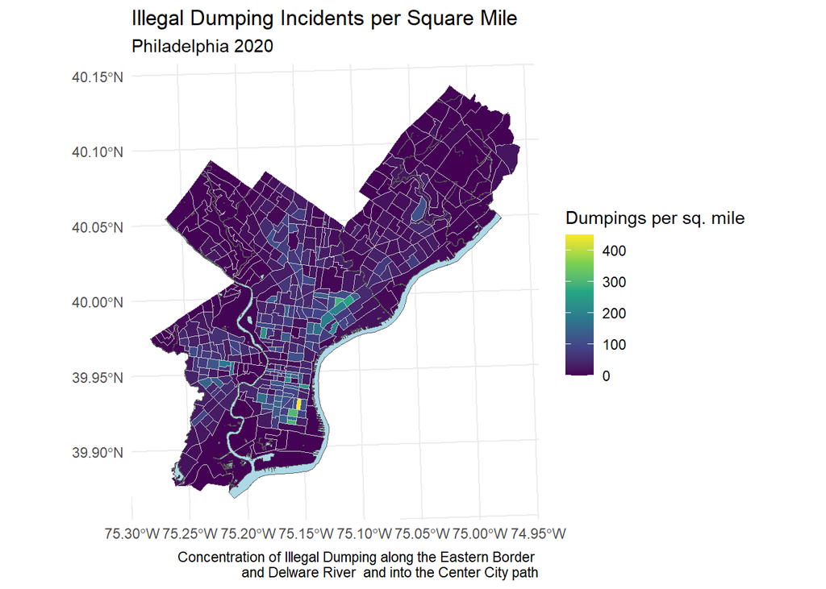

```r
ggplot()+
  geom_sf(data = acs2020_incidents,
          aes(fill = n_per_sqmi), color = "lightgray")+
  theme_minimal()+
  labs(title = 'Illegal Dumping Incidents per Square Mile', subtitle="Philadelphia 2020", caption = "Concentration of Illegal Dumping along the Eastern Border \n and Delware River  and into the Center City path", fill="Dumpings per sq. mile")+
  scale_fill_viridis_c()+
  geom_sf(data =philly_water, fill="lightblue")
```

# Knit the markdown and push it to your Github repo

Use the “knit” button on top to render the markdown into an HTML document. Don’t worry if it’s pretty or not, there’s time to worry about tat during the semester.

When you are done working (and whether you can get this to knit or not), push the newest changes from this rmd to your repo that you created at the beginning of class. How is this done?

Open up Github Desktop, load this repo as the “current repository” on the top left-hand menu.

You’ll see what files have changed - make some notes in your Github Desktop about what kinds of changes you made on the bottom left. Then “commit” these changes (at bottom right), and “push” them (on the top bar on the middle/right).

Now go and check your github page and see that your repo has updated.